# Texan Data Report

Andy Berrios

2022-05-09

```r
library(tidyverse)       # used for data import/manipulation
```

```r
library(ggplot2)         # used for data visualization
library(ggthemes)        # used to set aesthetic themes of data visualization
library(ggridges)        # used for data visualization
library(treemapify)      # used for data visualization
```

```r
# Loading CSV Data Sets
## Jobs
HTX_Work <- read.csv("Houston Industries.csv")
DTX_Work <- read.csv("Dallas Industries.csv")
SATX_Work <- read.csv("SanAnton Industries.csv")
HTX_Income <- read.csv("Houston Income.csv")
DTX_Income <- read.csv("Dallas Income.csv")
SATX_Income <- read.csv("SanAnton Income.csv")

## Cost of Living
HTX_House <- read.csv("Houston Property.csv")
DTX_House <- read.csv("Dallas Property.csv")
SATX_House <- read.csv("SanAnton Property.csv")
Commute <- read_csv("Commute.csv")
```

```r
## Demographics
HTX_People <- read.csv("Houston Diversity.csv")
DTX_People <- read.csv("Dallas Diversity.csv")
SATX_People <- read.csv("SanAnton Diversity.csv")
```

# Where is your future? Where will your next opportunity begin?

# Wether for future investments or a change in scenery let’s take a closer look at Houston, Dallas, and San Antonio!

According to Moving.com, there are three major components to look out for when planning a move or purchase: **Potential Job Perspectives, Cost of Living, and Demographics**.

# First, let’s consider what you need to survive in America: Money!

Each city will have different industries that thrive between it’s borders. Lets compare the different size and growth of all industries as a whole within their respective city!

```r
# Display Industries
## Here we are condensing (by way of Top 5 per year + City ) all the "JOB" data sets and assigning them to the respective city acronym
H <- HTX_Work %>%
  group_by(Year) %>%
  slice_max( order_by = Workforce.by.Industry.and.Gender, n = 5) %>%
  summarise(Industry_Population = mean(Workforce.by.Industry.and.Gender)) %>%
  mutate(City = "Houston")
D <- DTX_Work %>%
  group_by(Year) %>%
  slice_max( order_by = Workforce.by.Industry.and.Gender, n = 5) %>%
  summarise(Industry_Population = mean(Workforce.by.Industry.and.Gender)) %>%
  mutate(City = "Dallas")
SA <- SATX_Work %>%
  group_by(Year) %>%
  slice_max( order_by = Workforce.by.Industry.and.Gender, n = 5) %>%
  summarise(Industry_Population = mean(Workforce.by.Industry.and.Gender)) %>%
  mutate(City = "San Antonio")
```

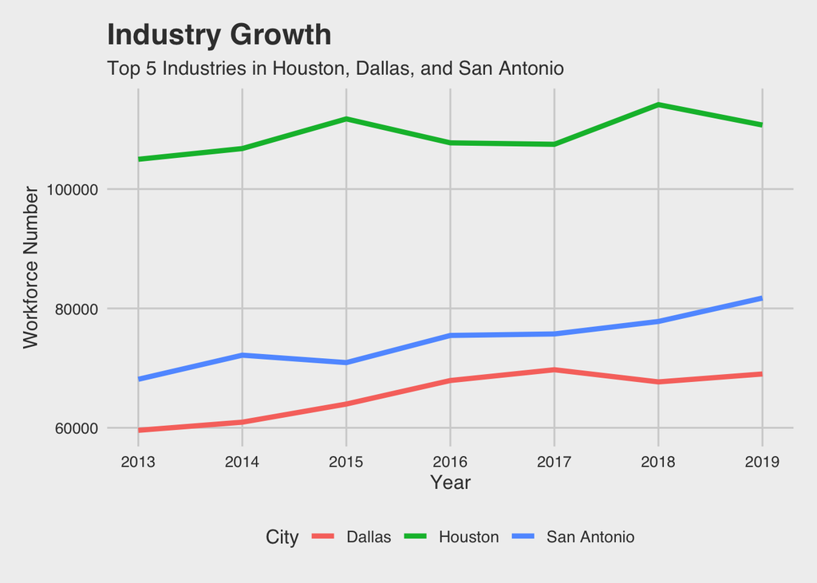

```r
## Overall Industry comparison
g <- rbind(H, D, SA)        # we are binding all condensed "JOB" data sets together to compare
options(scipen = 999)       # used repeatedly to ensure all numbers on both axis' are in a natural form
ggplot(g) +
  geom_line(aes( x = Year, y = Industry_Population, color = City), size = 1.5) +
  labs( title = "Industry Growth", subtitle = "Top 5 Industries in Houston, Dallas, and San Antonio", x = "Year", y = "Workforce Number", color = "City") +
  theme_fivethirtyeight() +
  theme(axis.title = element_text(),
        legend.text = element_text(size = 10)) +
  scale_x_continuous(breaks = 2013:2019)
```

At first glance one would say Houston is the go to place for job potential. However, looks can be deceiving, so lets take a closer look at the industries within each city!

# Houston

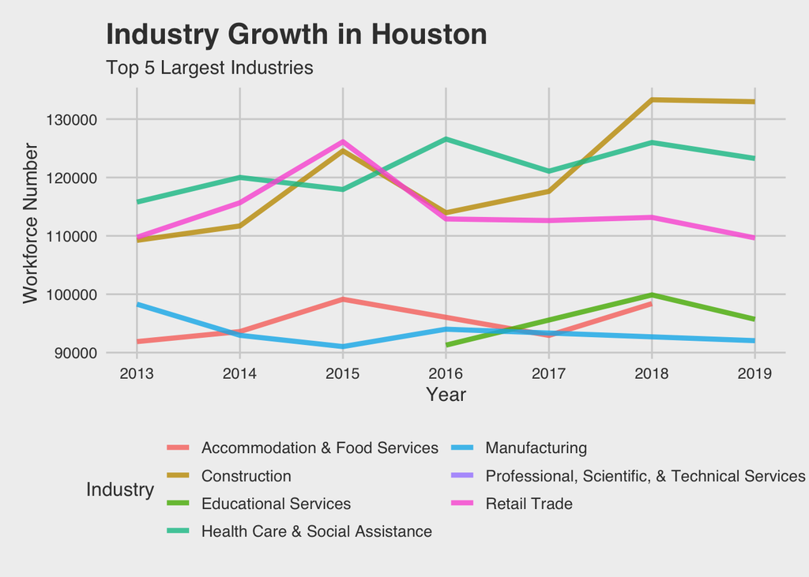

```r
# Filtering and displaying each city separately with their top 5 industries growth trends
HTX_Work %>%
  group_by(Year) %>%
  select(Industry, Workforce.by.Industry.and.Gender, Year, Geography) %>%
  slice_max( order_by = Workforce.by.Industry.and.Gender, n = 5) %>%
  ggplot(aes(x = Year, y = Workforce.by.Industry.and.Gender, color = Industry)) +
  geom_line( size= 1.5 , alpha = .8) +
  labs( title = "Industry Growth in Houston", subtitle = "Top 5 Largest Industries", x = "Year", y = "Workforce Number") +
  theme_fivethirtyeight() +
  theme(axis.title = element_text(),
        legend.text = element_text(size = 10)) +
  scale_x_continuous(breaks = 2013:2019) +
  guides(color = guide_legend(nrow = 4))
```

# Dallas

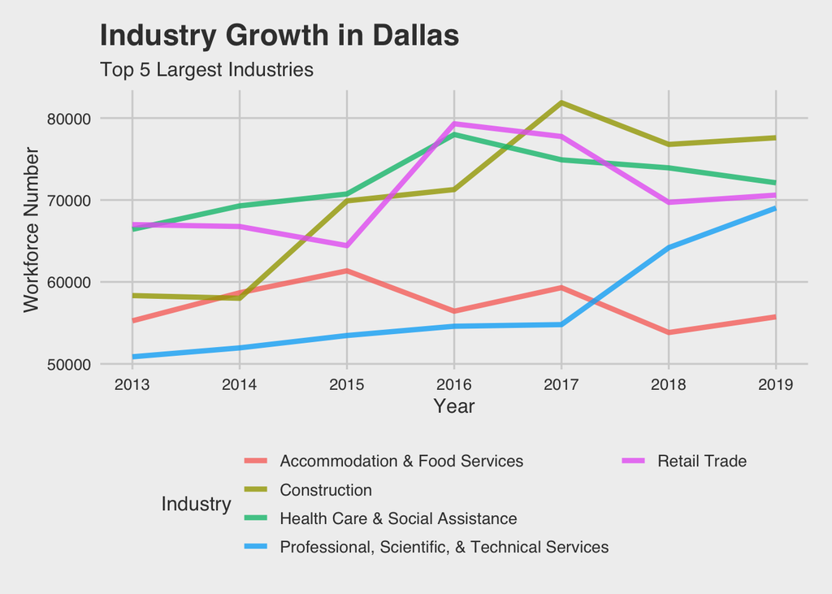

# San Antonio

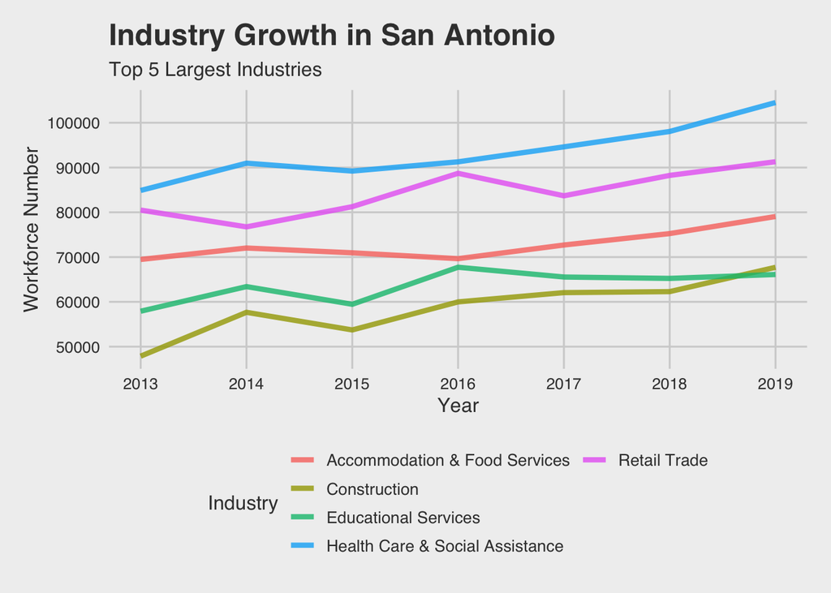

San Antonio comes in with a strong and stable economy with industry growth coming in at 4.10 %!

# Saleries

Now, let’s see how much you could potentially be making in each city!

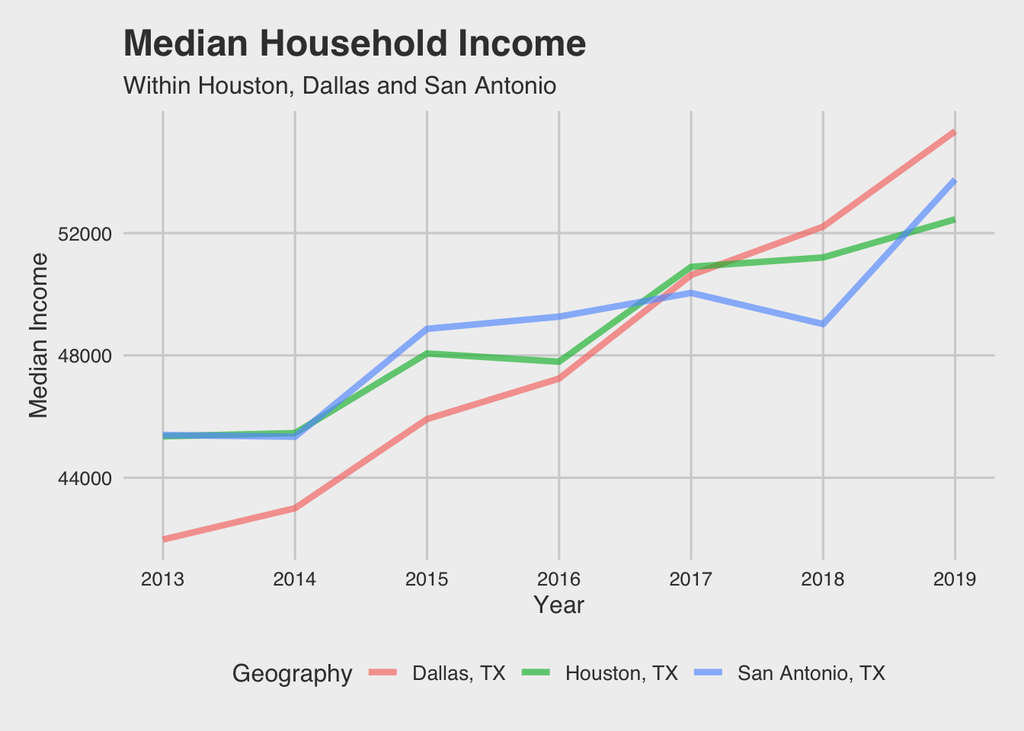

```r
options(scipen = 999)
# Here we rbinded without prior condensing and went straight to the filtering and visualization
# After much experimentation this method is the most efficient method to combine and display data. Because it eliminates the creation of multiple new variables and data sets.
rbind(HTX_Income, DTX_Income, SATX_Income) %>%
  filter(Geography == "Houston, TX" | Geography == "Dallas, TX" |Geography == "San Antonio, TX") %>% select(Year, Geography, Household.Income.by.Race) %>%
  ggplot(aes( x = Year, y = Household.Income.by.Race, color = Geography)) +
  geom_line( size = 1.5, alpha = .65) +
  labs( title = "Median Household Income", subtitle = "Within Houston, Dallas and San Antonio", x = "Year", y = "Median Income") +
  theme_fivethirtyeight() +
  theme(axis.title = element_text(),
        legend.text = element_text(size = 10)) +
  scale_x_continuous(breaks = 2013:2019)
```

Although all Incomes within their respective city are almost equivalent to each other, Dallas incomes are growing a faster rate than all.

# Moving on to the ‘Cost of Living’.

Lets glimpse into the housing market in each city as well as what an individual can expect when it comes to commute time to work.

# Housing Sales grouped by Purchace Price

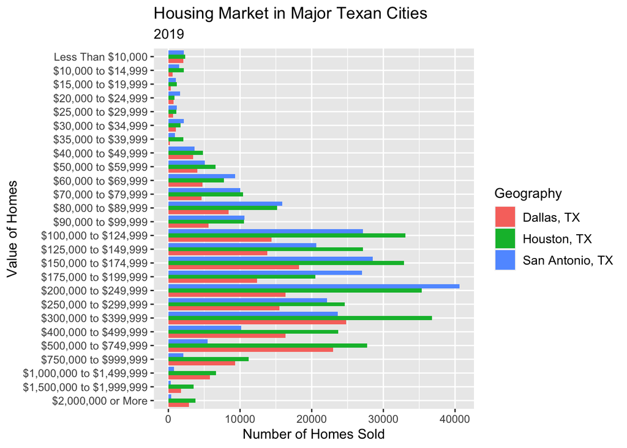

```r
# reverting back to condense, filter, and plot method
# Binding all housing data sets together into one table
Housing <- rbind(HTX_House, DTX_House,SATX_House)
# Filtering the binded data set to the relevent information on each cities housing market
Texas_Housing <- Housing %>% filter(Year == "2019") %>%
  filter(Geography == "Houston, TX" | Geography == "Dallas, TX" |Geography == "San Antonio, TX")

# Ploting each cities housing market
  ggplot(data = Texas_Housing,aes( x = reorder(Value.Bucket, -ID.Value.Bucket), y = Property.Value.by.Bucket, fill = Geography)) +
  geom_bar( stat = "identity" ,position = "dodge") + coord_flip() + labs( title = "Housing Market in Major Texan Cities", subtitle = "2019", x = "Value of Homes", y = "Number of Homes Sold") +  theme(axis.title = element_text(),
        legend.text = element_text(size = 10))
```

Quite apparent that homes are being sold at a higher rate within Houston. Let’s take a deeper look as to what these houses are going for.

# A closer look

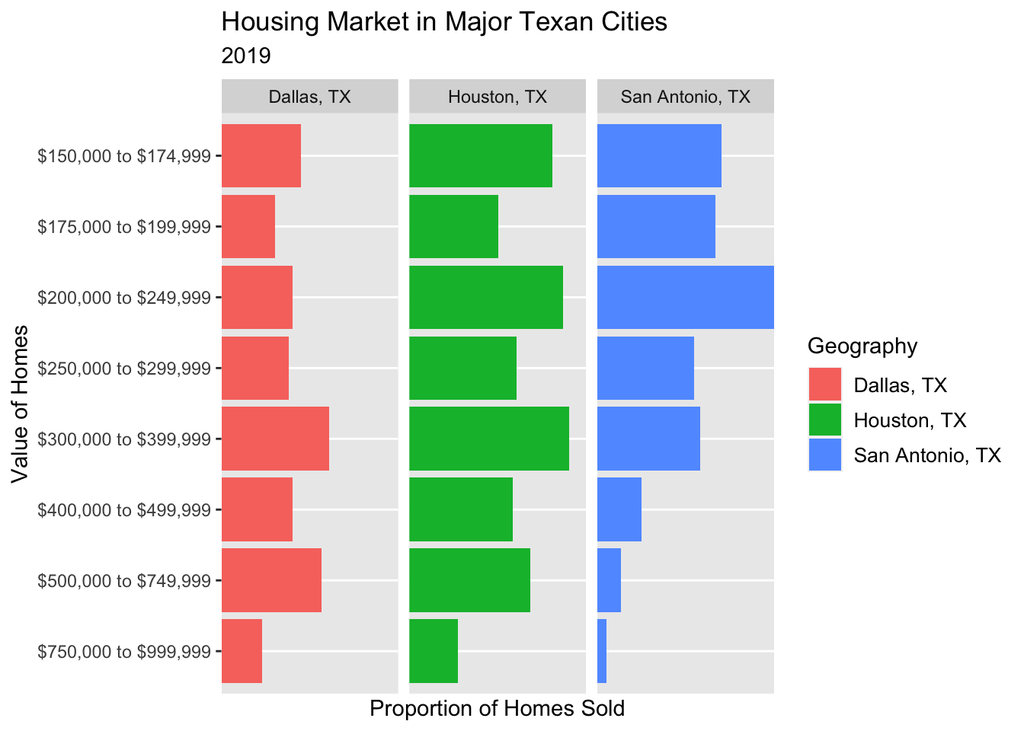

```r
# Because most homes are sold within a similar range we will crop to where the bulk of homes are sold at
# Facet Wrapping by City
ggplot(data = Texas_Housing %>% filter(ID.Value.Bucket == "15"|ID.Value.Bucket == "16"|ID.Value.Bucket == "17"|ID.Value.Bucket == "18"|ID.Value.Bucket == "19"|ID.Value.Bucket == "20"|ID.Value.Bucket == "21"|ID.Value.Bucket == "22"),aes( x = reorder(Value.Bucket, -ID.Value.Bucket), y = Property.Value.by.Bucket, fill = Geography)) +
  geom_bar( stat = "identity" ,position = "dodge")+ coord_flip()  + labs( title = "Housing Market in Major Texan Cities", subtitle = "2019", x = "Value of Homes", y = "Proportion of Homes Sold") +
  scale_y_discrete(guide = guide_axis(check.overlap = TRUE)) +
  facet_wrap(~Geography) +
  theme(axis.title = element_text(),
        legend.text = element_text(size = 10))
```

### In Houston most homes sold are sold at almost an even rate from $150,000 to $750,000

### In Dallas most homes sold are between $300,000 to $750,000

### In San Antonio most homes sold are between $200,000 to $250,000

Lots more options for ‘affordable housing’ in the San Antonio and Houston area! Directly correlating to the massive construction industry.

# Commuting

A commute can make a break the experience in a city. Constant traffic not only causes longer delays in driving, but also raises stress levels and environmental pollution.

# Gas Attack

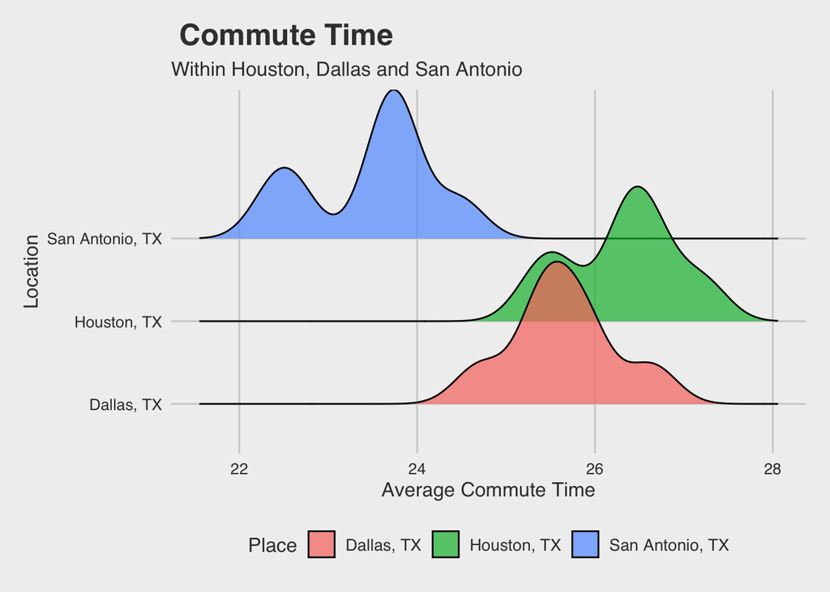

```r
# Commute
# Once again filtering our set to include only our respective cities
Texas_Commmute <- Commute %>% filter(Place == "Houston, TX" | Place == "Dallas, TX" |Place == "San Antonio, TX")

# Plotting our filtered dataset
  ggplot( Texas_Commmute , aes(x = `Average Commute Time`, y = Place)) + geom_density_ridges(aes(fill = Place), alpha = .7) +
    labs( title = " Commute Time", subtitle = "Within Houston, Dallas and San Antonio", x = "Average Commute Time", y = "Location") +
  theme_fivethirtyeight() +
  theme(axis.title = element_text(),
        legend.text = element_text(size = 10))
```

Houston Traffic; Can’t be beat!

# Demographics!

Who will be your neighbor? What will the culture of the city feel like?

# Lets check out the Diversity!

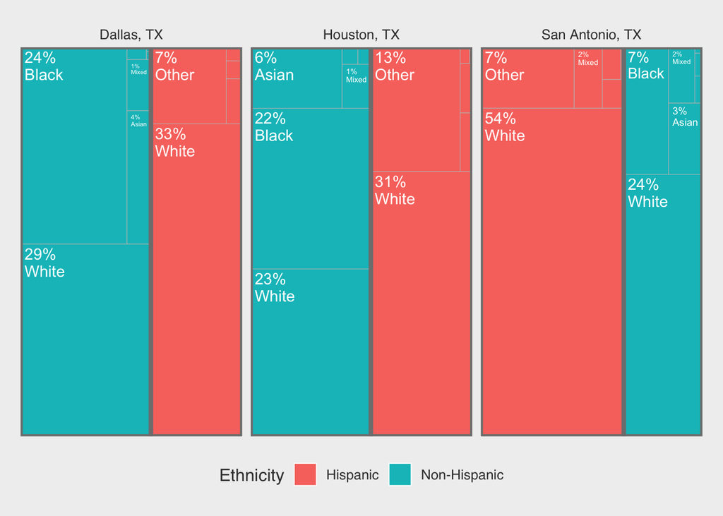

```r
# Repeating the binding, filtering, and plotting process
Texan_Folk <- rbind(HTX_People, DTX_People, SATX_People)
# Renaming some of our variables
Texan_Folk <- Texan_Folk %>%
  mutate(Race = case_when(ID.Race < 1 ~ "White", ID.Race < 2 ~ "Black", ID.Race < 3  ~ "Native American", ID.Race < 4 ~ "Asian", ID.Race < 5 ~ "Islander", ID.Race < 6 ~ "Other", ID.Race < 7 ~ "Mixed"))

# Mutating our created data set to itself to display a tree map that includes labels that are easier to comprehend
Texan_Folk <- Texan_Folk %>%
  mutate(Ethnicity = case_when(ID.Ethnicity < 1 ~ "Non-Hispanic", ID.Ethnicity < 2 ~ "Hispanic"))

ggplot(Texan_Folk %>% filter(Year == "2019") %>% group_by(Ethnicity), aes(area = Population,  fill = Ethnicity, label = paste(round(share * 100) , Race, sep = "%\n"), subgroup = Ethnicity)) +
  geom_treemap(layout = "squarified") +
  geom_treemap_subgroup_border() +
  geom_treemap_text(colour = "white", place = "topleft", reflow = T, size = 11) +
  facet_wrap(~Geography) +
  theme_fivethirtyeight()
```

San Antonio with a strong Hispanic presence. Over half of their population coming from Hispanic descent! Houston also matches diversity levels with San Antonio. Houston however, has the largest share of ethnicity inside its city limits. Lastly, Dallas will be the city with the weakest Hispanic presence.

# Summary

```
# Table to display findings and conclusions
```

[output not shown]

# References

```
https://www.moving.com/tips/how-to-choose-the-right-city-for-you/   # Used to
https://datausa.io
```